# Gathering Data

Ciara Duggan

10/15/2020

# AmfAR County-Level Opioid Prescription Data (per 100 persons)

This dataset was downloaded from the AmfAR Opioid and Health Indicators database. The specific page in the database can be found here: https://opioid.amfar.org/indicator/opioid_RxRate

For indicator “opioid_RxRate”, the “value” measure signifies the number of opioid prescriptions per 100 persons in the county.

From AmfAR: “This measure uses IQVIA data from pharmacies which dispense nearly 90% of all retail prescriptions in the US. It includes prescriptions paid for by commercial insurance, Medicaid, Medicare, or cash or equivalent. Cough and cold formulations containing opioids and buprenorphine products typically used to treat opioid use disorder are excluded, and IQVIA data does not include methadone dispensed through methadone maintenance treatment programs.”

Data Source: Centers for Disease Control and Prevention

Available at: https://www.cdc.gov/drugoverdose/maps/rxrate-maps.html

# AmfAR Data on Age-Adjusted Drug Poisoning Deaths per 100,000 (Modeled)

This dataset was downloaded from the AmfAR Opioid and Health Indicators database. The specific page in the database can be found here: https://opioid.amfar.org/indicator/drugdeathrate_est

For indicator “drugdeathrate_est”, the “value” measure signifies the estimated rate of death from drug poisoning, including both illicit and prescription drugs, per 100,000 U.S. standard population for 2000.

Data Source: Centers for Disease Control’s National Center for Health Statistics Data Visualization Gallery.

Available at: https://www.cdc.gov/nchs/data-visualization/drug-poisoning-mortality/

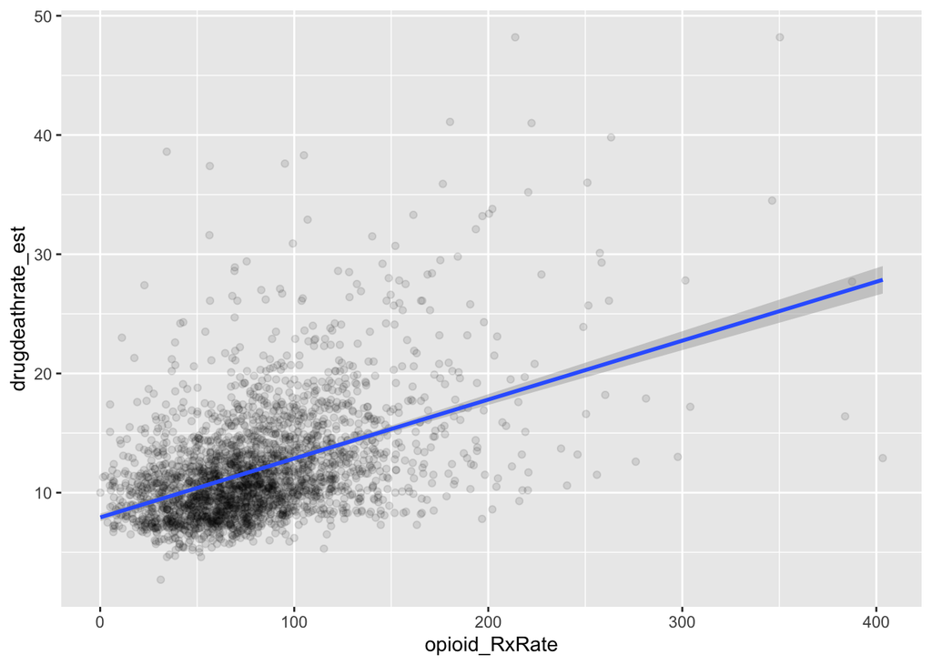